# Exam 3

Question :

```r
quantile(Exam3_Q30$Data, type = 6)
median(Exam3_Q30$Data, type = 6)

quantile(Exam3_Q30$Data, type = 4)
median(Exam3_Q30$Data, type = 4)
```

[output not shown]

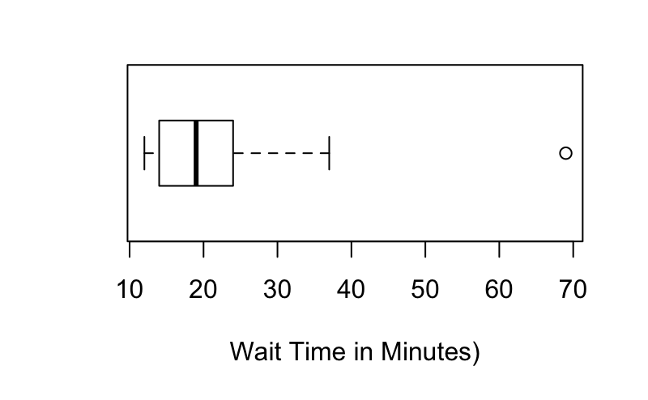

```r
boxplot(Exam3_Q5, xlab="Wait Time in Minutes)", names =c("Wait"), horizontal = TRUE)
```

```r
boxplot(Exam3_Q5, xlab="Wait Time (in Minutes)", names =c("Wait"), horizontal = TRUE, plot = FALSE, stats = FALSE)
```

```
$stats
     [,1]
[1,]   12
[2,]   14
[3,]   19
[4,]   24
[5,]   37

$n
[1] 9

$conf
         [,1]
[1,] 13.73333
[2,] 24.26667

$out
[1] 69

$group
[1] 1

$names
[1] "Wait"
```

```r
EnvStats::summaryStats(Exam3_Q5$Data)
```

```
              N Mean      SD Median Min Max
Exam3_Q5$Data 9   25 18.1934     19  12  69
```

```r
quantile(Exam3_Q5$Data, type = 6)
```

```
  0%  25%  50%  75% 100%
12.0 13.5 19.0 30.5 69.0
```

```r
iqr(Exam3_Q5$Data)
```

```
[1] 10
```

```r
30.5+(1.5*17)
```

```
[1] 56
```

`r`r median(Exam3_Q6$Data)

[output not shown]

`r`r stat(Exam3_Q6$Data)

[output not shown]

Question 19

Weighted mean to recompute the averages of student grades by rows

`r`r weighted.mean(Exam3_Q19$`Row Average Score`, Exam3_Q19$`Number of Students`)

```
[1] 85.70357
```

`r`r mean(Exam3_Q19$`Row Average Score`)

```
[1] 85.22
```

Question 20

CHECK QUESTION 20

Question 21

Standard Deviation

`r`r summary(Exam3_Q21$Scores)

```
   Min. 1st Qu.  Median    Mean 3rd Qu.    Max.
    168     172     174     178     185     190
```

`r`r mean(Exam3_Q21$Scores)

```
[1] 178
```

`r`r geoMean(Exam3_Q21$Scores)

```
[1] 177.822
```

`r`r sd(Exam3_Q21$Scores)

```
[1] 8.640988
```

`r`r weighted_average=weighted.mean(Exam3_Q21$Scores,c(1,1,1,1,1,1,1),na.rm=TRUE)

Question 23

Covariance of GRE and GPA

`r`r cov(Exam3_Q23$GRE, Exam3_Q23$GPA)

```
[1] 57.5
```

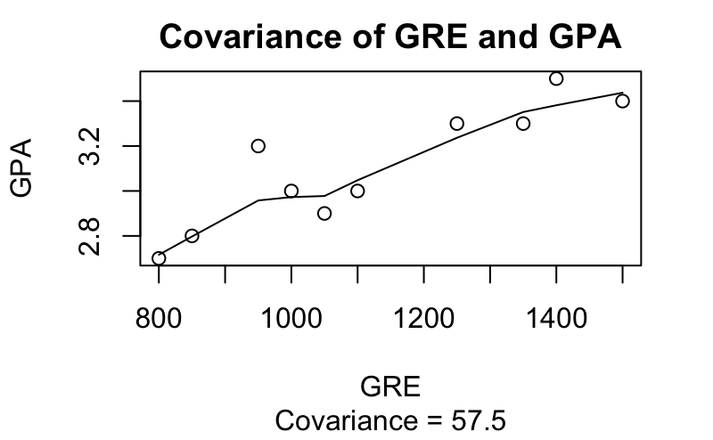

Question 27

Finding the mean of the values

```r
mean(Exam3_Q27$Data)
```

```
[1] 18
```

```r
geoMean(Exam3_Q27$Data)
```

```
[1] 16.24096
```

```r
pop.geoMean(Exam3_Q27$Data)
```

```
[1] 16.24096
```

```r
sd(Exam3_Q30$Data)
```

```
[1] 8.640988
```

```r
pop.sd(Exam3_Q30$Data)
```

```
[1] 8
```

```r
pop.var(Exam3_Q30$Data)
```

```
[1] 64
```

```r
summary(Exam3_Q30)
```

```
      Data
 Min.   : 8
 1st Qu.:12
 Median :14
 Mean   :18
 3rd Qu.:25
 Max.   :30
```

```r
pop.sd(Exam3_Q5$Data)
```

```
[1] 17.15291
```

Question 32

Finding the 30th Percentile

```r
quantile(Exam3_Q32$Data, type = 6)
```

```
  0%  25%  50%  75% 100%
   1    2    5   12   18
```

```r
Quantile(Exam3_Q32$Data, type = 6, )
```

```
[1]  1  2  5 12 18
```

```r
quantile(Exam3_Q32$Data, probs = seq(0,1, by = 0.1), type = 6)
```

```
  0%  10%  20%  30%  40%  50%  60%  70%
 1.0  1.0  1.6  2.8  4.2  5.0  9.0 11.2
 80%  90% 100%
14.4 18.0 18.0
```

Question 33 & 34

IQR & 75th %tile

```r
IQR(Exam3_Q33$Data, type = 6)
```

```
[1] 6
```

```r
quantile(Exam3_Q33$Data, type = 6)
```

```
  0%  25%  50%  75% 100%
 2.0  2.5  3.0  8.5 12.0
```

Question 35

median of frequency chart

```r
median(c(rep(5,15),rep(15,75),rep(25,55),(rep(35,55))))
```

```
[1] 25
```

Question 37

```r
geoMean(Exam3_Q37$Scores)
```

```
[1] 177.822
```

Question 38 (use Exam3_Q33)

```r
sd(Exam3_Q33$Data)
```

```
[1] 4.062019
```

```r
"use top answer"
```

```
[1] "use top answer"
```

```r
pop.sd(Exam3_Q33$Data)
```

```
[1] 3.63318
```

Question 40

Mean Salary = 80,000 SD=6,000 what is SD with a 2% raise of all salaries

```r
80000*1.02
```

```
[1] 81600
```

```r
6000*1.02
```

```
[1] 6120
```

Question 42

Geometric mean is greater than the arithmetic mean?

```r
geoMean(Exam3_Q33$Data)
```

```
[1] 4.042823
```

```r
mean(Exam3_Q33$Data)
```

```
[1] 5
```

Question 43

Addidas average growthrate

```r
killpack.return.calc(Exam3_Q43$Growth)
```

```
[1] 0.1183494
```

Question #48 (same data as #5)

find IQR

```r
IQR(Exam3_Q5$Data, type = 6)
```

```
[1] 17
```

Question #50

Median over Philidelphia temperatures

```r
median(Exam3_Q50$Temperture)
```

```
[1] 73.5
```

```r
KillpackStatsPackage::killpack.return.calc(Exam3_Q43$Growth)
```

```
[1] 0.1183494
```

```r
pop.sd(Exam3_Q50$Temperture)
```

```
[1] 6.817945
```

```r
pop.var(Exam3_Q50$Temperture)
```

```
[1] 46.48438
```

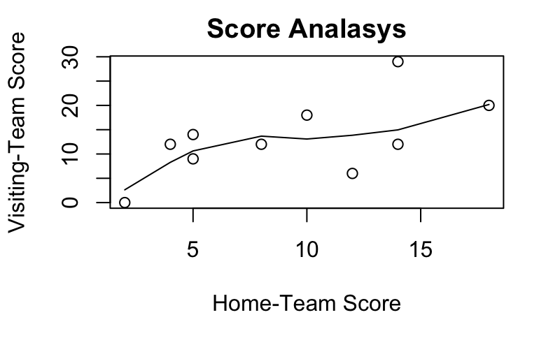

```r
plot(mlb_elo$score1, mlb_elo$score2, xlab = "Home-Team Score", ylab = "Visiting-Team Score", main = "Score Analasys")
lines(lowess(mlb_elo$score1, mlb_elo$score2))
```

[figure not shown]

```r
plot(mlb_elo$score1, mlb_elo$score2, type = "n")
```

```r
IQR(Exam3_Q33$Data, type = 6)
```

```
[1] 6
```